# Diari 2 - Primeres exploracions

Nom del grup

22/11/2024

## Qüestions abordades

*Escriviu les qüestions que heu decidit abordar.*

1. Quina distribució segueix els temps d’execució de cada algoritme? Segueix una normal, una exponencial, una uniforme, etc …?
2. La mida del vector és independent del temps d’execució de cada algoritme?

## Comentaris

*Qualsevol cosa que vulgueu afegir sobre les qüestions.*

## Variables relacionades

*Quines variables del vostre conjunt de dades, o d’altres, us sembla que caldrà considerar?*

## Resultats

*Resums i gràfics obtinguts.*

1. Per respondre a la qüestió **1**, podem visualitzar cada algoritme amb un histograma.

#### Bubblesort

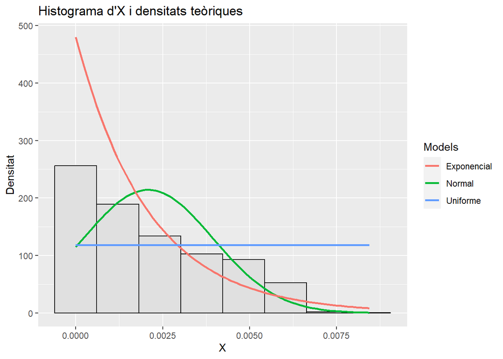

#### Quicksort

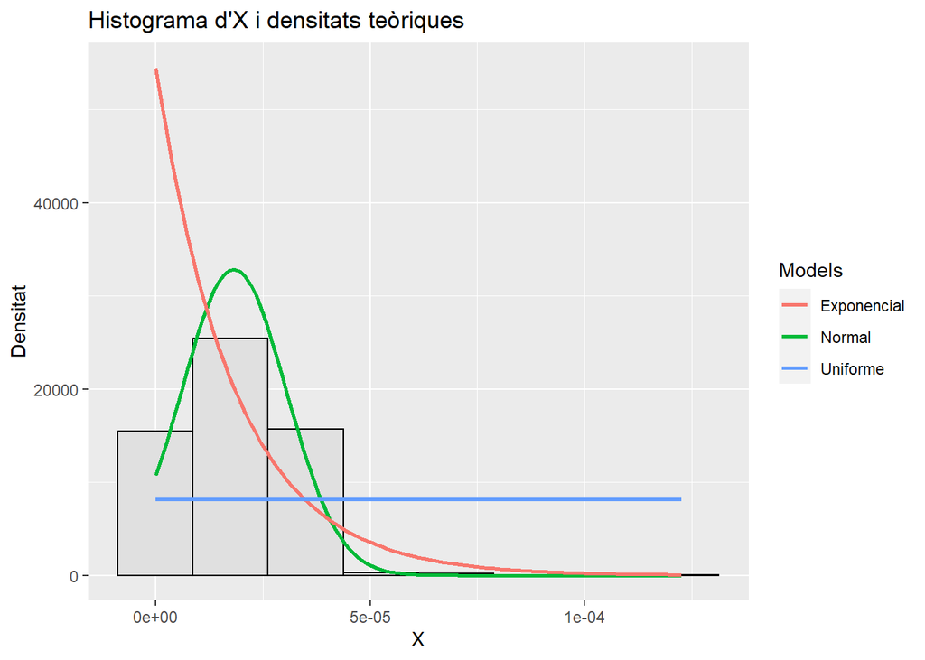

#### Mergesort

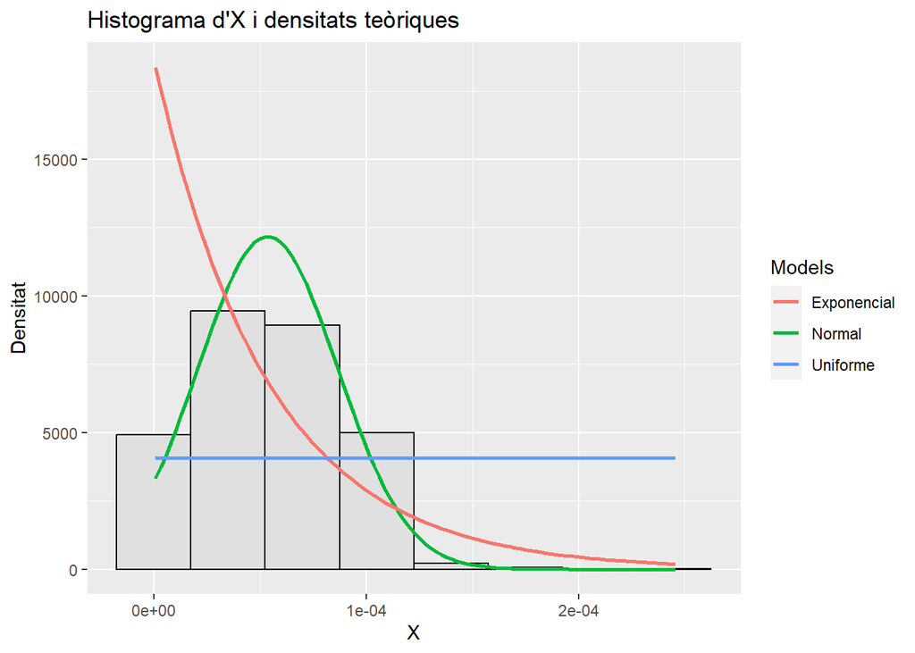

Podem veure que els temps dels tres algoritmes segueixen una normal, i en el cas del bublesort una exponencial, però no ho veiem del tot bé, ja que els histogrames resultants depen molt de com hem agafat la mostra.

Per veure-ho millor podriem ajustar els errors, per exemple de quicksort i mergesort.

```r
f = function(x, a,b,c) a + b * x + c * x * log(x)
mod.mergesort = nls(mergesort~a + b*mida+c*mida*log(mida), data = simulacions, start = list(a = 1, b = 1, c = 1))
mod.quicksort = nls(quicksort~a + b*mida+c*mida*log(mida), data = simulacions, start = list(a = 1, b = 1, c = 1))
```

Podem desciure els models amb la funció `summary()`.

```r
summary(mod.mergesort)
```

```
##
## Formula: mergesort ~ a + b * mida + c * mida * log(mida)
##
## Parameters:
##     Estimate Std. Error t value Pr(>|t|)
## a -2.974e-07  5.564e-07  -0.535   0.5930
## b  8.907e-08  1.011e-08   8.814   <2e-16 ***
## c  2.760e-09  1.424e-09   1.938   0.0527 .
## ---
## Signif. codes:  0 '***' 0.001 '**' 0.01 '*' 0.05 '.' 0.1 ' ' 1
##
## Residual standard error: 9.48e-06 on 4997 degrees of freedom
##
## Number of iterations to convergence: 2
## Achieved convergence tolerance: 1.136e-07
```

```r
summary(mod.quicksort)
```

```
##
## Formula: quicksort ~ a + b * mida + c * mida * log(mida)
##
## Parameters:
##     Estimate Std. Error t value Pr(>|t|)
## a  2.956e-07  2.277e-07   1.298    0.194
## b -4.738e-09  4.137e-09  -1.145    0.252
## c  6.285e-09  5.829e-10  10.782   <2e-16 ***
## ---
## Signif. codes:  0 '***' 0.001 '**' 0.01 '*' 0.05 '.' 0.1 ' ' 1
##
## Residual standard error: 3.88e-06 on 4997 degrees of freedom
##
## Number of iterations to convergence: 2
## Achieved convergence tolerance: 1.246e-08
```

I visualitzar la recta que ajusta cadascun dels models.

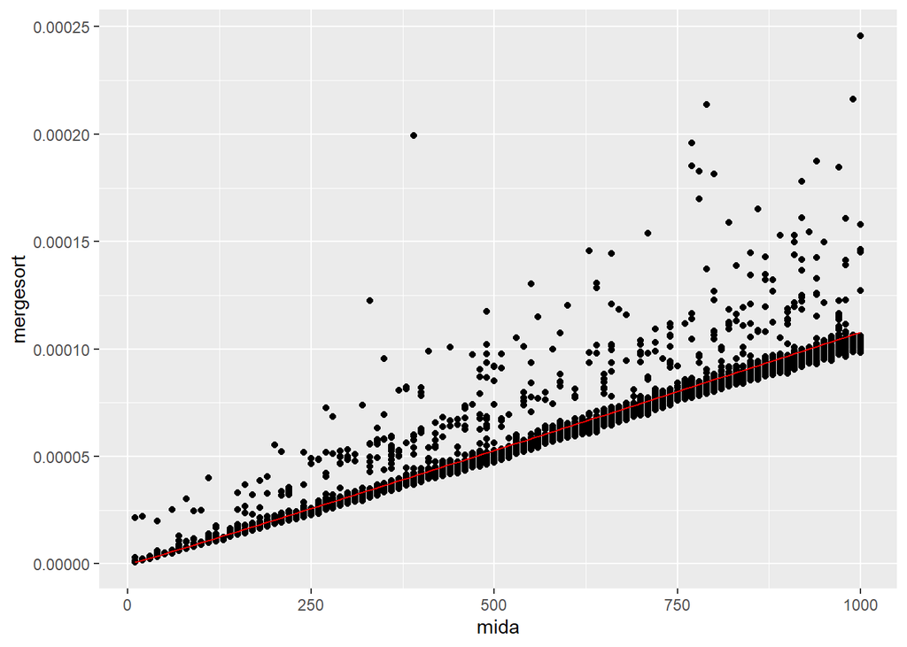

```r
coefs = coef(mod.mergesort)
f_opt = function(x) f(x, coefs[1], coefs[2], coefs[3])
ggplot(data = simulacions) +
  geom_point(aes(x = mida, y = mergesort)) +
  geom_function(fun = f_opt, col = 'red')
```

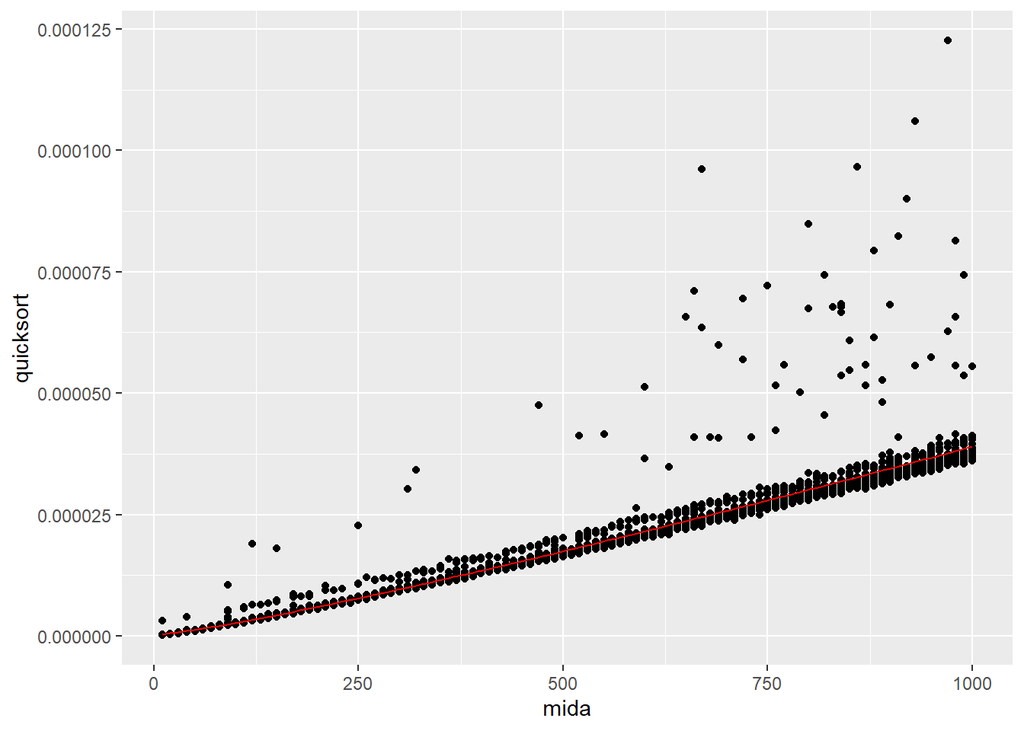

```r
coefs = coef(mod.quicksort)
ggplot(data = simulacions) +
  geom_point(aes(x = mida, y = quicksort)) +
  geom_function(fun = f_opt, col = 'red')
```

Ara podem fer.

```r
lm.mergesort = lm(mergesort~mida, data=simulacions)
lm.quicksort = lm(quicksort~mida, data=simulacions)
```

I podem visualitzar la recta com.

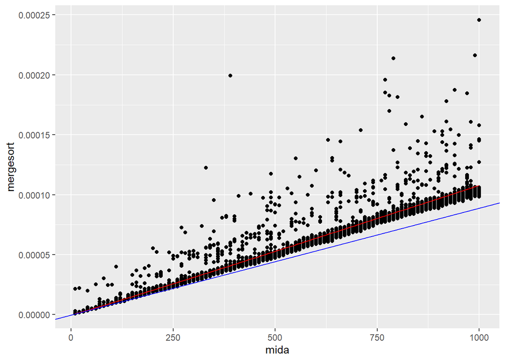

```r
coefs = coef(mod.mergesort)
ggplot(data = simulacions) +
  geom_point(aes(x = mida, y = mergesort)) +
  geom_function(fun = f_opt, col = 'red') +
  geom_abline(intercept = coef(mod.mergesort)[1], slope = coef(mod.mergesort)[2], col = 'blue')
```

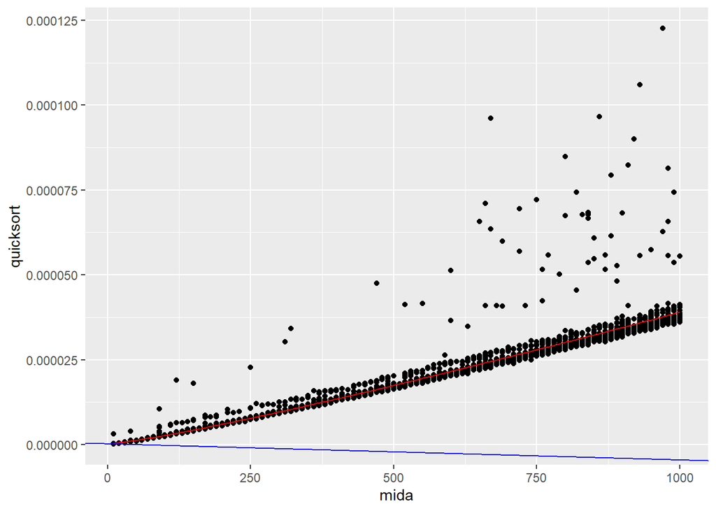

```r
coefs = coef(mod.quicksort)
ggplot(data = simulacions) +
  geom_point(aes(x = mida, y = quicksort)) +
  geom_function(fun = f_opt, col = 'red') +
  geom_abline(intercept = coef(mod.quicksort)[1], slope = coef(mod.quicksort)[2], col = 'blue')
```

Ara podem calcular l’SQR.

```r
e1 = residuals(mod.mergesort)
SQR1 = sum(e1^2)
e2 = residuals(mod.quicksort)
SQR2 = sum(e2^2)
SQR1
```

```
## [1] 4.491109e-07
```

```r
SQR2
```

```
## [1] 7.524118e-08
```

I l’SQT

```r
SQT1 = sum((simulacions$mergesort - mean(simulacions$mergesort))^2)
SQT2 = sum((simulacions$quicksort - mean(simulacions$quicksort))^2)
SQT1
```

```
## [1] 5.366486e-06
```

```r
SQT2
```

```
## [1] 7.374893e-07
```

Que ens permetra saber la porporció d’errors de quicksort i mergesort, a través del seu coeficient de determinacio, $R^2$.

```r
R21 = SQR1/SQT1
R22 = SQR2/SQT2
```

I el que hem explicat de cada algoritme.

```r
1 - R21
```

```
## [1] 0.9163119
```

```r
1 - R22
```

```
## [1] 0.8979766
```

Quin dels dos explica millor el log n?

```r
mod.mergesort2 = lm(mergesort~mida+I(mida*log(mida)), data = simulacions)
SQR21 = sum(residuals(mod.mergesort2)^2)
1-SQR21/SQT1
```

```
## [1] 0.9163119
```

```r
mod.quicksort2 = lm(quicksort~mida+I(mida*log(mida)), data = simulacions)
SQR22 = sum(residuals(mod.quicksort2)^2)
1-SQR22/SQT2
```

```
## [1] 0.8979766
```

D’on veiem que tant el quicksort com el mergesort expliquen bastant bé log n. I ara ens podem preguntar, i el bubblesort?

```r
lm.bubblesort = lm(bubblesort~mida+I(mida*log(mida)), data=simulacions)
SQR3 = sum(residuals(lm.bubblesort)^2)
SQT3 = sum((simulacions$bubblesort - mean(simulacions$bubblesort))^2)
1-SQR3/SQT3
```

```
## [1] 0.9892375
```

D’on veiem que bubblesort explica molt millor el logaritme que els altres algoritmes.

```r
lm.bubblesort = lm(bubblesort~mida+I(mida^2), data=simulacions)
SQR3 = sum(residuals(lm.bubblesort)^2)
SQT3 = sum((simulacions$bubblesort - mean(simulacions$bubblesort))^2)
1-SQR3/SQT3
```

```
## [1] 0.9928102
```

I si provem amb el quadrat de la mida *$O(n^2)$*, també ho explica bastant més que els altres algoritmes.

## Noves qüestions

*Dubtes, preguntes i qüestions que han sorgit durant l’estudi.*

1. Quina relació hi ha entre la mida de vector i l’algoritme? És a dir, si les dues variables tenen una correlació molt alta o molt baixa?
2. La variància entre el temps obtingut i el teòric fa que l’algoritme sigui més fiable? *calcular l’error relatiu*

## Material addicional

*Opcional, si heu consultat alguna web o font. Indiqueu els enllaços.*

## Llista de tasques

*Opcional, si us va bé anar indicant les feines que cal fer i com les penseu repartir entre els membres de l’equip.*